# Comparing recount-brain and MetaSRA ‘UBERON:0000955’

Leonardo Collado-Torres

Lieber Institute for Brain Development, Johns Hopkins Medical Campus  
Center for Computational Biology, Johns Hopkins University

lcolladotor@gmail.com

13 November 2020

`MetaSRA` ([Bernstein, Doan, and Dewey, 2017](https://doi.org/10.1093/bioinformatics/btx334)) contains “normalized metadata for the Sequence Read Archive” which is constructed using the SRA Run Info tables. The `MetaSRA` ([Bernstein, Doan, and Dewey, 2017](https://doi.org/10.1093/bioinformatics/btx334)) authors provide a website where you can query the samples by term such as the `brain` which leads to metasra.biostat.wisc.edu/?and=UBERON:0000955. As of April 15th, 2019 they have 17,890 brain samples from 342 studies listed.

# 1 Data setup

We can download the data using the following link:

```bash
## April 15, 2019
wget http://metasra.biostat.wisc.edu/api/v01/samples.csv?and=UBERON:0000955
```

Next, we load the required R packages.

```r
library('recount')
library('tidyverse')
```

Now we can get all the required data

```r
## Read the MetaSRA data
metasra <- read.csv('samples.csv?and=UBERON:0000955')
head(metasra)
```

```
##    study_id                                                               study_title  sample_id sample_name
## 1 SRP052546 Single Cell Analysis Program-Transcriptomics (SCAP-T) (UC San Diego site) SRS1341305
## 2 SRP052546 Single Cell Analysis Program-Transcriptomics (SCAP-T) (UC San Diego site) SRS1341312
## 3 SRP052546 Single Cell Analysis Program-Transcriptomics (SCAP-T) (UC San Diego site) SRS1341782
## 4 SRP052546 Single Cell Analysis Program-Transcriptomics (SCAP-T) (UC San Diego site) SRS1341315
## 5 SRP052546 Single Cell Analysis Program-Transcriptomics (SCAP-T) (UC San Diego site) SRS1341318
## 6 SRP052546 Single Cell Analysis Program-Transcriptomics (SCAP-T) (UC San Diego site) SRS1341322
##     sample_type sample_type_confidence                                     mapped_ontology_ids
## 1 primary cells              0.8799537 CL:0000540, EFO:0003534, UBERON:0003100, UBERON:0013541
## 2 primary cells              0.8799537 CL:0000540, EFO:0003534, UBERON:0003100, UBERON:0013541
## 3 primary cells              0.8799537 CL:0000540, EFO:0003534, UBERON:0003100, UBERON:0013541
## 4 primary cells              0.8799537 CL:0000540, EFO:0003534, UBERON:0003100, UBERON:0013541
## 5 primary cells              0.8799537 CL:0000540, EFO:0003534, UBERON:0003100, UBERON:0013541
## 6 primary cells              0.8799537 CL:0000540, EFO:0003534, UBERON:0003100, UBERON:0013541
##                                                    mapped_ontology_terms
## 1 neuron, dorsal telencephalon, female organism, Brodmann (1909) area 10
## 2 neuron, dorsal telencephalon, female organism, Brodmann (1909) area 10
## 3 neuron, dorsal telencephalon, female organism, Brodmann (1909) area 10
## 4 neuron, dorsal telencephalon, female organism, Brodmann (1909) area 10
## 5 neuron, dorsal telencephalon, female organism, Brodmann (1909) area 10
## 6 neuron, dorsal telencephalon, female organism, Brodmann (1909) area 10
##                                                                                                                                                                                                                                                                                                          …
## 1 analyte type: RNA; biospecimen repository: SCAP-T; body site: Left Brodmann's Area 10 (Prefrontal Cortex); gap_accession: phs000834; gap_consent_code: 1; gap_consent_short_name: GRU; gap_parent_phs: phs000833; histological type: Brain cell (Neuron); is technical control: Yes; is tumor: No; mole…
## 2 analyte type: RNA; biospecimen repository: SCAP-T; body site: Left Brodmann's Area 10 (Prefrontal Cortex); gap_accession: phs000834; gap_consent_code: 1; gap_consent_short_name: GRU; gap_parent_phs: phs000833; histological type: Brain cell (Neuron); is technical control: Yes; is tumor: No; mole…
## 3 analyte type: RNA; biospecimen repository: SCAP-T; body site: Left Brodmann's Area 10 (Prefrontal Cortex); gap_accession: phs000834; gap_consent_code: 1; gap_consent_short_name: GRU; gap_parent_phs: phs000833; histological type: Brain cell (Neuron); is technical control: Yes; is tumor: No; mole…
## 4 analyte type: RNA; biospecimen repository: SCAP-T; body site: Left Brodmann's Area 10 (Prefrontal Cortex); gap_accession: phs000834; gap_consent_code: 1; gap_consent_short_name: GRU; gap_parent_phs: phs000833; histological type: Brain cell (Neuron); is technical control: Yes; is tumor: No; mole…
## 5 analyte type: RNA; biospecimen repository: SCAP-T; body site: Left Brodmann's Area 10 (Prefrontal Cortex); gap_accession: phs000834; gap_consent_code: 1; gap_consent_short_name: GRU; gap_parent_phs: phs000833; histological type: Brain cell (Neuron); is technical control: Yes; is tumor: No; mole…
## 6 analyte type: RNA; biospecimen repository: SCAP-T; body site: Left Brodmann's Area 10 (Prefrontal Cortex); gap_accession: phs000834; gap_consent_code: 1; gap_consent_short_name: GRU; gap_parent_phs: phs000833; histological type: Brain cell (Neuron); is technical control: Yes; is tumor: No; mole…
```

```r
## Get the unique 342 studies
metasra_study <- unique(metasra$study_id)
stopifnot(length(metasra_study) == 342)

## Get the recount2 metadata
meta <- all_metadata()
```

```
## 2020-11-13 16:25:45 downloading the metadata to /tmp/RtmpK9pZcs/metadata_clean_sra.Rdata
```

```r
## Load the predictions
PredictedPhenotypes <- add_predictions(version = '0.0.03')
```

```
## 2020-11-13 16:25:47 downloading the predictions to /tmp/RtmpK9pZcs/PredictedPhenotypes_v0.0.03.rda
```

```
## Loading objects:
##   PredictedPhenotypes
```

```r
PredictedPhenotypes_latest <- add_predictions(version = '0.0.06')
```

```
## 2020-11-13 16:25:48 downloading the predictions to /tmp/RtmpK9pZcs/PredictedPhenotypes_v0.0.06.rda
```

```
## Loading objects:
##   PredictedPhenotypes
```

```r
## Get recount-brain using the recount Bioconductor package
recount_brain <- add_metadata(source = 'recount_brain_v2')
```

```
## 2020-11-13 16:25:48 downloading the recount_brain metadata to /tmp/RtmpK9pZcs/recount_brain_v2.Rdata
```

```
## Loading objects:
##   recount_brain
```

# 2 General comparison

## 2.1 `MetaSRA` to `recount_brain`

First, we can check how many studies with at least one brain sample as detected with `MetaSRA` are in either `recount2` or `recount_brain`.

```r
## using tolower() doesn't change any of these numbers
addmargins(table(
    'In recount2' = metasra_study %in% recount_abstract$project,
    'In recount-brain' = metasra_study %in% unique(recount_brain$sra_study_s)
))
```

```
##            In recount-brain
## In recount2 FALSE TRUE Sum
##       FALSE   195    0 195
##       TRUE    100   47 147
##       Sum     295   47 342
```

```r
## In percent
addmargins(table(
    'In recount2' = metasra_study %in% recount_abstract$project,
    'In recount-brain' = metasra_study %in% unique(recount_brain$sra_study_s)
)) / length(metasra_study) * 100
```

```
##            In recount-brain
## In recount2     FALSE      TRUE       Sum
##       FALSE  57.01754   0.00000  57.01754
##       TRUE   29.23977  13.74269  42.98246
##       Sum    86.25731  13.74269 100.00000
```

```r
## Studies in MetaSRA and recount2 but not in recount_brain
studies_to_check <- metasra_study[
    metasra_study %in% recount_abstract$project &
    !metasra_study %in% unique(recount_brain$sra_study_s)
]
```

As a check, anything in `recount_brain` has to be in `recount2` by construction. We’ll later take a deeper look at the 100 studies present in `MetaSRA` and `recount2` yet absent from `recount_brain` (excluding TCGA).

At the sample level we can find samples present in `recount_brain` absent from `recount2` which is not unexpected (`recount2` was built to be only human RNA-seq samples). All the samples present in `MetaSRA` and `recount2` yet absent from `recount_brain` from the studies we wanted to check.

```r
## using tolower() doesn't change any of these numbers
addmargins(table(
    'In recount2' = metasra$sample_id %in% meta$sample,
    'In recount-brain' = metasra$sample_id %in% recount_brain$sra_sample_s
))
```

```
##            In recount-brain
## In recount2 FALSE  TRUE   Sum
##       FALSE 13291  1411 14702
##       TRUE   2026  1162  3188
##       Sum   15317  2573 17890
```

```r
## in percent
addmargins(table(
    'In recount2' = metasra$sample_id %in% meta$sample,
    'In recount-brain' = metasra$sample_id %in% recount_brain$sra_sample_s
)) / nrow(metasra) * 100
```

```
##            In recount-brain
## In recount2      FALSE       TRUE        Sum
##       FALSE  74.292901   7.887088  82.179989
##       TRUE   11.324762   6.495249  17.820011
##       Sum    85.617663  14.382337 100.000000
```

```r
## Samples in MetaSRA and recount2 but not in recount_brain
samples_to_check <- metasra$sample_id[
    metasra$sample_id %in% meta$sample &
    !metasra$sample_id %in% recount_brain$sra_sample_s
]

## All of them are from the studies we need to check
table(unique(meta$project[meta$sample %in% samples_to_check]) %in%
    studies_to_check)
```

```
##
## TRUE
##   97
```

Note that these results exclude TCGA since they don’t have SRA sample IDs.

```r
table('Has SRA sample id' = !is.na(recount_brain$sra_sample_s), recount_brain$Dataset)
```

```
##
## Has SRA sample id GTEX recount_brain_v1 TCGA
##             FALSE    0                0  707
##             TRUE  1409             4431    0
```

## 2.2 `recount_brain` to `MetaSRA`

We can also do the reverse check and ask which studies or samples present in `recount_brain` are present in `MetaSRA`.

```r
## At the study level
addmargins(table(
    'In MetaSRA (project)' = unique(recount_brain$sra_study_s) %in%
    metasra_study
))
```

```
## In MetaSRA (project)
## FALSE  TRUE   Sum
##    17    47    64
```

```r
## in percent
addmargins(table(
    'In MetaSRA (project)' = unique(recount_brain$sra_study_s) %in% metasra_study
)) / length(unique(recount_brain$sra_study_s)) * 100
```

```
## In MetaSRA (project)
##    FALSE     TRUE      Sum
##  26.5625  73.4375 100.0000
```

```r
## At the sample level
## Check whether it's all the large study SRP025982
addmargins(table(
    'In MetaSRA (sample)' = recount_brain$sra_sample_s %in% metasra$sample_id,
    'SRP025982' = recount_brain$sra_study_s == 'SRP025982',
    'Dataset' = recount_brain$Dataset, useNA = 'ifany'
))
```

```
## , , Dataset = GTEX
##
##                    SRP025982
## In MetaSRA (sample) FALSE TRUE <NA>  Sum
##               FALSE     0    0    0    0
##               TRUE   1409    0    0 1409
##               Sum    1409    0    0 1409
##
## , , Dataset = recount_brain_v1
##
##                    SRP025982
## In MetaSRA (sample) FALSE TRUE <NA>  Sum
##               FALSE   659 2475    0 3134
##               TRUE    874  423    0 1297
##               Sum    1533 2898    0 4431
##
## , , Dataset = TCGA
##
##                    SRP025982
## In MetaSRA (sample) FALSE TRUE <NA>  Sum
##               FALSE     0    0  707  707
##               TRUE      0    0    0    0
##               Sum       0    0  707  707
##
## , , Dataset = Sum
##
##                    SRP025982
## In MetaSRA (sample) FALSE TRUE <NA>  Sum
##               FALSE   659 2475  707 3841
##               TRUE   2283  423    0 2706
##               Sum    2942 2898  707 6547
```

```r
## Ok, it's not all SRP025982 so we can drop that comparison
## and show the table in percent
addmargins(table(
    'In MetaSRA (sample)' = recount_brain$sra_sample_s %in% metasra$sample_id,
    'Dataset' = recount_brain$Dataset, useNA = 'ifany'
)) / nrow(recount_brain) * 100
```

```
##                    Dataset
## In MetaSRA (sample)      GTEX recount_brain_v1      TCGA       Sum
##               FALSE   0.00000         47.86925  10.79884  58.66809
##               TRUE   21.52131         19.81060   0.00000  41.33191
##               Sum    21.52131         67.67985  10.79884 100.00000
```

From these checks, we can see that 26.6% of the `recount_brain` studies and 58.7% of the samples are missing from `MetaSRA`, respectively.

# 3 Studies to check

Lets take a deeper look at the 100 studies present in `MetaSRA` and `recount2` yet absent from `recount_brain`. The `recount` package already has the study abstract and number of samples information. We can then construct the URL to explore manually these discrepant studies. Next, we can look at the `phenopredict` ([Ellis, Collado-Torres, Jaffe, and Leek, 2018](https://doi.org/10.1093/nar/gky102)) predictions we used (version 0.0.03) for selecting the studies as well and the latest (0.0.06) predictions. The prediction table also includes a `reported_tissue`. Along with the predictions and the reported tissue, we can also look at `MetaSRA` to identify the number of brain samples according to each source and the percent of brain samples per study. We can then evaluate whether the study passed or not our selection criteria of at least 4 brain samples with 70 percent of the study samples coming from the brain.

```r
## Lets get the study-level information already present in the recount package
discrepant <- subset(recount_abstract, project %in% studies_to_check)

## Does the abstract mention the word brain?
discrepant$mentions_brain <- grepl('brain', tolower(discrepant$abstract))

## Next, the url
discrepant$url <- paste0(
    'https://trace.ncbi.nlm.nih.gov/Traces/sra/?study=',
    discrepant$project
)

## Order by decreasing number of samples
discrepant <- discrepant[order(discrepant$number_samples, decreasing = TRUE), ]

## Get information at the sample level for each project
discrepant_studies_samples <- map(discrepant$project, function(x) {
    y <- meta$run[meta$project == x]
    m <- match(y, PredictedPhenotypes$sample_id)
    m2 <- match(y, PredictedPhenotypes_latest$sample_id)

    data.frame(
        prediction_original = PredictedPhenotypes$predicted_tissue[m],
        prediction_latest = PredictedPhenotypes_latest$predicted_tissue[m2],
        sharq = PredictedPhenotypes_latest$reported_tissue[m2],
        project = x,
        sample_id = y,
        stringsAsFactors = FALSE
    )
})

## Summarize the information found for each study
discrepant <- cbind(discrepant, map_dfr(discrepant_studies_samples, function(x) {

    data.frame(
        brain_n_original = sum(x$prediction_original == 'Brain', na.rm = TRUE),
        brain_n_latest = sum(x$prediction_latest == 'Brain', na.rm = TRUE),
        brain_n_sharq = sum(x$sharq == 'Brain', na.rm = TRUE),
        brain_n_metasra = sum(metasra$study_id == unique(x$project)),
        brain_percent_original = sum(x$prediction_original == 'Brain',
            na.rm = TRUE) / nrow(x) * 100,
        brain_percent_latest = sum(x$prediction_latest == 'Brain',
            na.rm = TRUE) / nrow(x) * 100,
        brain_percent_sharq = sum(x$sharq == 'Brain',
            na.rm = TRUE) / nrow(x) * 100,
        brain_percent_metasra = sum(metasra$study_id == unique(x$project)) /
            nrow(x) * 100,
        stringsAsFactors = FALSE
    )

}))

## Does it match the original criterial of at least 4 samples and greater than
## 70% brain samples in the study?
discrepant$criteria_original <- discrepant$number_samples >= 4 &
    discrepant$brain_percent_original > 70
discrepant$criteria_latest <- discrepant$number_samples >= 4 &
    discrepant$brain_percent_latest > 70
discrepant$criteria_sharq <- discrepant$number_samples >= 4 &
    discrepant$brain_percent_sharq > 70
discrepant$criteria_metasra <- discrepant$number_samples >= 4 &
    discrepant$brain_percent_metasra > 70

## Check the original criteria is all FALSE since they are absent from recount_brain
stopifnot(all(!discrepant$criteria_original))
```

Now that we have our detailed table for these 100 studies, we can look into them in more detail.

```r
addmargins(with(discrepant,
    table(criteria_latest, criteria_sharq, criteria_metasra)))
```

```
## , , criteria_metasra = FALSE
##
##                criteria_sharq
## criteria_latest FALSE TRUE Sum
##           FALSE    68    4  72
##           TRUE      0    0   0
##           Sum      68    4  72
##
## , , criteria_metasra = TRUE
##
##                criteria_sharq
## criteria_latest FALSE TRUE Sum
##           FALSE    19    4  23
##           TRUE      2    3   5
##           Sum      21    7  28
##
## , , criteria_metasra = Sum
##
##                criteria_sharq
## criteria_latest FALSE TRUE Sum
##           FALSE    87    8  95
##           TRUE      2    3   5
##           Sum      89   11 100
```

From the above output we can see that 28 of the 100 studies would match our study criteria had we used `MetaSRA`, which includes 5 studies that now also match our criteria using the version 0.0.06 predictions.

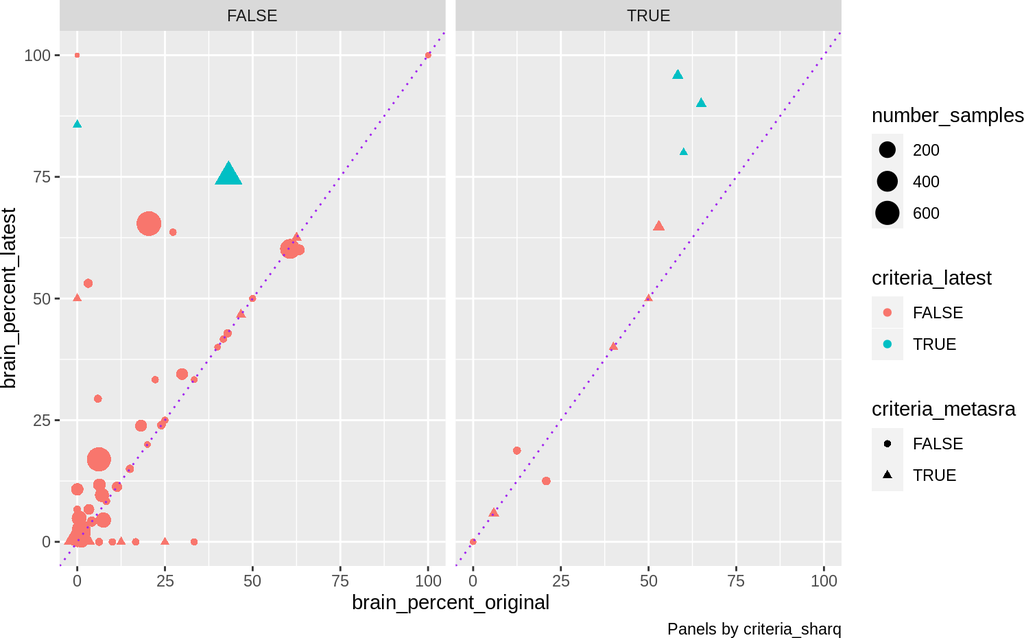

```r
## all
ggplot(discrepant,
    aes(x = brain_percent_original, y = brain_percent_latest,
        color = criteria_latest, size = number_samples,
        shape = criteria_metasra)) +
    geom_point() +
    facet_grid( ~ criteria_sharq) +
    geom_abline(linetype = 3, color = 'purple') +
    labs(caption = 'Panels by criteria_sharq')
```

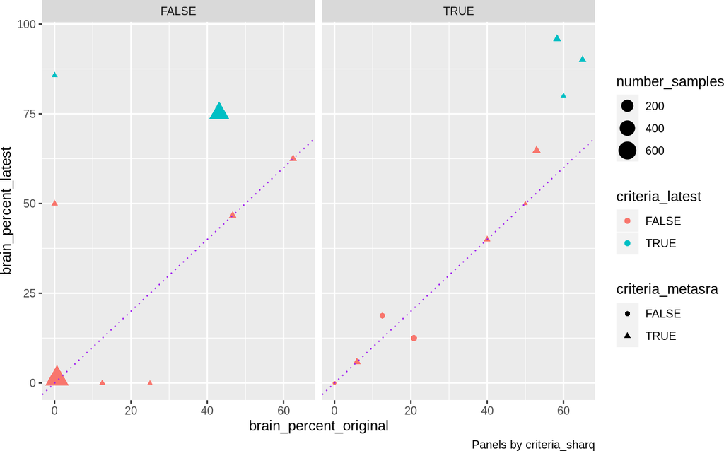

```r
## just those with some TRUE criteria
ggplot(subset(discrepant,
    criteria_sharq | criteria_metasra | criteria_latest),
    aes(x = brain_percent_original, y = brain_percent_latest,
        color = criteria_latest, size = number_samples,
        shape = criteria_metasra)) +
    geom_point() +
    facet_grid( ~ criteria_sharq) +
    geom_abline(linetype = 3, color = 'purple') +
    labs(caption = 'Panels by criteria_sharq')
```

There are 4 studies that only pass the selection criteria based on the `reported_tissue` information present in the predictions table. The `reported_tissue` was extracted from [SHARQ prototype](http://www.cs.cmu.edu/~ckingsf/sharq/) as described in the `phenopredict` manuscript ([Ellis, Collado-Torres, Jaffe, and Leek, 2018](https://doi.org/10.1093/nar/gky102)).

```r
subset(discrepant, criteria_sharq & !(criteria_metasra | criteria_latest))
```

```
##     number_samples species
## 847             24   human
## 789             16   human
## 268              4   human
## 341              4   human
##                                                                                                                                                                                                                                                                                                          …
## 847                                                                                                                                                                                                                                              Purpose: The purpose of this experiment is to identify a…
## 789                                                                                                                                                                                                                                                                                                      …
## 268                                                                                                      Establishing the functional roles of genetic variants remains a significant challenge in the post-genomic era. Here, we present a method, allele-specific alternative mRNA processing (ASARP), t…
## 341 RNA editing enhances the diversity of gene products at the post-transcriptional level. Approaches for genome-wide identification of RNA editing face two main challenges: separating true editing sites from false discoveries and accurate estimation of editing levels. We developed an approach to…
##       project mentions_brain                                                        url brain_n_original brain_n_latest
## 847 SRP032165          FALSE https://trace.ncbi.nlm.nih.gov/Traces/sra/?study=SRP032165                5              3
## 789 SRP028738           TRUE https://trace.ncbi.nlm.nih.gov/Traces/sra/?study=SRP028738                2              3
## 268 SRP006970          FALSE https://trace.ncbi.nlm.nih.gov/Traces/sra/?study=SRP006970                0              0
## 341 SRP009659          FALSE https://trace.ncbi.nlm.nih.gov/Traces/sra/?study=SRP009659                0              0
##     brain_n_sharq brain_n_metasra brain_percent_original brain_percent_latest brain_percent_sharq brain_percent_metasra
## 847            24               6               20.83333                12.50                 100                  25.0
## 789            12               2               12.50000                18.75                  75                  12.5
## 268             4               1                0.00000                 0.00                 100                  25.0
## 341             4               2                0.00000                 0.00                 100                  50.0
##     criteria_original criteria_latest criteria_sharq criteria_metasra
## 847             FALSE           FALSE           TRUE            FALSE
## 789             FALSE           FALSE           TRUE            FALSE
## 268             FALSE           FALSE           TRUE            FALSE
## 341             FALSE           FALSE           TRUE            FALSE
```

These are the 5 studies that would pass the selection criteria with the latest predictions which would all pass it with `MetaSRA` data.

```r
subset(discrepant, criteria_latest)
```

```
##      number_samples species
## 1669            466   human
## 438              24   human
## 665              20   human
## 1862              7   human
## 567               5   human
##                                                                                                                                                                                                                                                                                                          …
## 1669                                                                                                                                                                                                                                                                                                     …
## 438                                                                                                                                                                                                                                                                                                      …
## 665  MicroRNAs (miRNAs) are small (20-22 nucleotides) regulatory non-coding RNAs that strongly influence gene expression. Most prior studies addressing the role of miRNAs in neurodegenerative diseases (NDs) have focused on individual controls (n = 2), AD (n = 5), dementia with Lewy bodies (n = 4)…
## 1862                                                                                                                                                                                                                                                                                                     …
## 567                                                                                                                                                                                                                                                                                                      …
##        project mentions_brain                                                        url brain_n_original
## 1669 SRP057196           TRUE https://trace.ncbi.nlm.nih.gov/Traces/sra/?study=SRP057196              201
## 438  SRP013825           TRUE https://trace.ncbi.nlm.nih.gov/Traces/sra/?study=SRP013825               14
## 665  SRP021130           TRUE https://trace.ncbi.nlm.nih.gov/Traces/sra/?study=SRP021130               13
## 1862 SRP063669           TRUE https://trace.ncbi.nlm.nih.gov/Traces/sra/?study=SRP063669                0
## 567  SRP017777           TRUE https://trace.ncbi.nlm.nih.gov/Traces/sra/?study=SRP017777                3
##      brain_n_latest brain_n_sharq brain_n_metasra brain_percent_original brain_percent_latest brain_percent_sharq
## 1669            350             0             466               43.13305             75.10730             0.00000
## 438              23            23              24               58.33333             95.83333            95.83333
## 665              18            19              20               65.00000             90.00000            95.00000
## 1862              6             0               7                0.00000             85.71429             0.00000
## 567               4             5               5               60.00000             80.00000           100.00000
##      brain_percent_metasra criteria_original criteria_latest criteria_sharq criteria_metasra
## 1669                   100             FALSE            TRUE          FALSE             TRUE
## 438                    100             FALSE            TRUE           TRUE             TRUE
## 665                    100             FALSE            TRUE           TRUE             TRUE
## 1862                   100             FALSE            TRUE          FALSE             TRUE
## 567                    100             FALSE            TRUE           TRUE             TRUE
```

To explore the table in more detail, open the `discrepant_studies.csv` file.

```r
write.csv(discrepant, file = 'discrepant_studies.csv')
```

# 4 Reproducibility

This document was made possible thanks to `MetaSRA` ([Bernstein, Doan, and Dewey, 2017](https://doi.org/10.1093/bioinformatics/btx334)) and :

- R ([R Core Team, 2020](https://www.R-project.org/))
- *BiocStyle* ([Oleś, Morgan, and Huber, 2020](https://github.com/Bioconductor/BiocStyle))
- *knitcitations* ([Boettiger, 2019](https://CRAN.R-project.org/package=knitcitations))
- *knitr* ([Xie, 2014](http://www.crcpress.com/product/isbn/9781466561595))
- *rmarkdown* ([Allaire, Xie, McPherson, Luraschi, et al., 2020](https://github.com/rstudio/rmarkdown))
- *sessioninfo* ([Csárdi, core, Wickham, Chang, et al., 2018](https://CRAN.R-project.org/package=sessioninfo))
- *tidyverse* ([Wickham, Averick, Bryan, Chang, et al., 2019](https://doi.org/10.21105/joss.01686))

Code for creating this document

```r
## Create the vignette
library('rmarkdown')
system.time(render('metasra_comp.Rmd', 'BiocStyle::html_document'))
```

Reproducibility information for this document.

```r
## Reproducibility info
proc.time()
```

```
##    user  system elapsed
##  75.865   5.957 135.840
```

```r
message(Sys.time())
```

```
## 2020-11-13 16:25:52
```

```r
options(width = 120)
library('sessioninfo')
```

[session information not shown]

# 5 Bibliography

This document was generated using *BiocStyle* ([Oleś, Morgan, and Huber, 2020](https://github.com/Bioconductor/BiocStyle)) with *knitr* ([Xie, 2014](http://www.crcpress.com/product/isbn/9781466561595)) and *rmarkdown* ([Allaire, Xie, McPherson, Luraschi, et al., 2020](https://github.com/rstudio/rmarkdown)) running behind the scenes.

Citations made with *knitcitations* ([Boettiger, 2019](https://CRAN.R-project.org/package=knitcitations)) and the bibliographical file is available here.

Bibliography file

[1] J. Allaire, Y. Xie, J. McPherson, J. Luraschi, et al. *rmarkdown: Dynamic Documents for R*. R package version 2.5. 2020. <URL: https://github.com/rstudio/rmarkdown>.

[2] M. N. Bernstein, A. Doan, and C. N. Dewey. “MetaSRA: normalized human sample-specific metadata for the Sequence Read Archive”. In: *Bioinformatics* 33.18 (May. 2017). Ed. by J. Wren, pp. 2914-2923. DOI: 10.1093/bioinformatics/btx334. <URL: https://doi.org/10.1093/bioinformatics/btx334>.

[3] C. Boettiger. *knitcitations: Citations for ‘Knitr’ Markdown Files*. R package version 1.0.10. 2019. <URL: https://CRAN.R-project.org/package=knitcitations>.

[4] G. Csárdi, R. core, H. Wickham, W. Chang, et al. *sessioninfo: R Session Information*. R package version 1.1.1. 2018. <URL: https://CRAN.R-project.org/package=sessioninfo>.

[5] S. E. Ellis, L. Collado-Torres, A. E. Jaffe, and J. T. Leek. “Improving the value of public RNA-seq expression data by phenotype prediction”. In: *Nucl. Acids Res.* (2018). DOI: 10.1093/nar/gky102. <URL: https://doi.org/10.1093/nar/gky102>.

[6] A. Oleś, M. Morgan, and W. Huber. *BiocStyle: Standard styles for vignettes and other Bioconductor documents*. R package version 2.16.1. 2020. <URL: https://github.com/Bioconductor/BiocStyle>.

[7] R Core Team. *R: A Language and Environment for Statistical Computing*. R Foundation for Statistical Computing. Vienna, Austria, 2020. <URL: https://www.R-project.org/>.

[8] H. Wickham, M. Averick, J. Bryan, W. Chang, et al. “Welcome to the tidyverse”. In: *Journal of Open Source Software* 4.43 (2019), p. 1686. DOI: 10.21105/joss.01686.

[9] Y. Xie. “knitr: A Comprehensive Tool for Reproducible Research in R”. In: *Implementing Reproducible Computational Research*. Ed. by V. Stodden, F. Leisch and R. D. Peng. ISBN 978-1466561595. Chapman and Hall/CRC, 2014. <URL: http://www.crcpress.com/product/isbn/9781466561595>.